# 431 Class 09

Thomas E. Love, Ph.D.

2023-09-26

## Our Agenda

- Ingesting the `dm1000` data using `read_Rds()`
- Estimating a population mean based on a sample
  - With a regression model, with a t test, with the bootstrap
  - Interpreting a confidence interval estimate
- Comparing Means from Two (Independent) Samples
  - Plotting with facets, Comparing Densities, Boxplots
  - Using a regression model or a t test
  - Using the `bootdif()` function from the `Love-boost.R` script
  - Assumptions of our interval estimates
- Saving a tibble as an R data set with `write_rds()`

## Today’s R Packages

```r
library(Hmisc)
library(kableExtra)

library(broom)
library(janitor)
library(naniar)
library(patchwork)
library(tidyverse) # always load tidyverse last

theme_set(theme_test()) # trying a new theme
knitr::opts_chunk$set(comment = NA)
```

- As usual, `#| message: false` silences messages here.

## Sourcing in the Love-boost.R Script

```r
source("https://raw.githubusercontent.com/THOMASELOVE/431-data/main/data-and-code/Love-boost.R")
```

This consists of four functions at present:

- `bootdif()`
- `saifs.ci()`
- `twobytwo()`
- `retrodesign()`

all of which we’ll use during the semester.

## The `dm1000` tibble

```r
url_dm1000 <- "https://github.com/THOMASELOVE/431-data/raw/main/data-and-code/dm_1000.Rds"

dm1000 <- read_rds(url_dm1000)
dm1000
```

```
# A tibble: 1,000 × 17
   subject   age insurance  n_income    ht    wt   sbp   dbp   a1c   ldl tobacco
   <chr>   <dbl> <fct>         <dbl> <dbl> <dbl> <dbl> <dbl> <dbl> <dbl> <fct>
 1 M-0001     55 Medicaid      29853  1.63 103.    145    70   6.4   221 Current
 2 M-0002     52 Commercial    31248  1.75 112.    151    77   8.5   116 Never
 3 M-0003     69 Medicare      23362  1.65  74.9   127    73   8.9    52 Former
 4 M-0004     57 Medicaid      26033  1.63  81.4   125    74   6.8   122 Never
 5 M-0005     68 Medicare      85374  1.69  92.6   120    73  10.3    94 Never
 6 M-0006     56 Medicaid      31273  1.71  54.6   127    75  12.3    NA Current
 7 M-0007     54 Commercial    25445  1.68  81.6   114    81   6.5   100 Current
 8 M-0008     45 Medicare      67526  1.69  80.6   166   110   5.4    NA Never
 9 M-0009     61 Medicare      15203  1.91  86.7   111    77   7.1    71 Former
10 M-0010     63 Medicaid      17628  1.86 123.    146   102   8.9    73 <NA>
# ℹ 990 more rows
# ℹ 6 more variables: statin <dbl>, eye_exam <dbl>, race_ethnicity <fct>,
#   sex <fct>, county <fct>, residence <fct>
```

## Estimating a Population Mean

Suppose our sample in `dm1000` is a random sample from the population of all Cuyahoga County residents between the ages of 31-75 receiving care for diabetes.

What’s a good estimate for the mean Hemoglobin A1c of the people in that population?

- How would we make this estimate using our data?
- What would we want to know about the data?
- DTDP

## Hemoglobin A1c in `dm1000`

```r
p1 <- ggplot(dm1000, aes(sample = a1c)) +
  geom_qq(col = "firebrick1") +
  geom_qq_line(col = "black") +
  theme(aspect.ratio = 1) +
  labs(title = "Normal Q-Q plot: dm1000 a1c")

p2 <- ggplot(dm1000, aes(x = a1c)) +
  geom_histogram(aes(y = stat(density)),
                 bins = 20, fill = "firebrick1", col = "khaki") +
  stat_function(fun = dnorm,
                args = list(mean = mean(dm1000$a1c, na.rm = TRUE),
                            sd = sd(dm1000$a1c, na.rm = TRUE)),
                col = "black", lwd = 1.5) +
  labs(title = "Density Function: dm1000 a1c")

p3 <- ggplot(dm1000, aes(x = a1c, y = "")) +
  geom_boxplot(fill = "firebrick1", outlier.color = "firebrick1") +
  labs(title = "Boxplot: dm1000 a1c", y = "")

p1 + (p2 / p3 + plot_layout(heights = c(4,1)))
```

## Hemoglobin A1c in `dm1000`

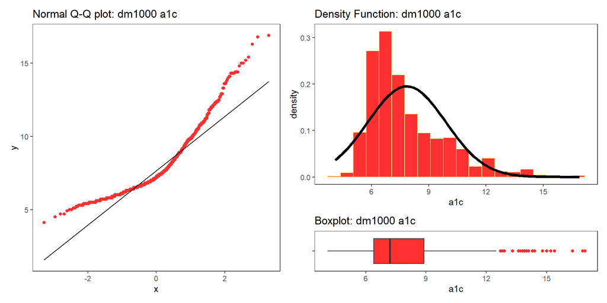

## Numerical Summaries of A1c

- Should we assume the A1c values are drawn from a Normal distribution?

```r
mosaic::favstats(~ a1c, data = dm1000) |>
  kbl(digits = 2) |>
  kable_styling(font_size = 32, full_width = FALSE)
```

|  | min | Q1 | median | Q3 | max | mean | sd | n | missing |
| --- | --- | --- | --- | --- | --- | --- | --- | --- | --- |
|  | 4.1 | 6.4 | 7.2 | 8.9 | 16.9 | 7.85 | 2.04 | 985 | 15 |

- The `kbl()` and `kable_styling()` functions are from the `kableExtra` package.
  - Read more about [kableExtra in its vignette](https://cran.r-project.org/web/packages/kableExtra/vignettes/awesome_table_in_html.html).
- We could also have used the `gt` package here.

## What if we assume the A1cs are Normally distributed?

Then we could use a linear regression model to obtain a 95% confidence interval for the population mean.

```r
m1 <- lm(a1c ~ 1, data = dm1000)
tidy(m1, conf.int = TRUE, conf.level = 0.95) |>
  select(estimate, conf.low, conf.high)
```

```
# A tibble: 1 × 3
  estimate conf.low conf.high
     <dbl>    <dbl>     <dbl>
1     7.85     7.73      7.98
```

## What is the model we’ve fit here?

```r
m1
```

```
Call:
lm(formula = a1c ~ 1, data = dm1000)

Coefficients:
(Intercept)
      7.853
```

- This “intercept only” model simply predicts the mean value of our outcome, `a1c`.

## Interpreting this interval? (1/3)

- Our 95% confidence interval for the population mean A1c is (7.73, 7.98).

We are estimating the mean of the **population** based on a mean from our *sample* of 1000 observations taken (at random, we assume) from that population.

- Sadly, this **doesn’t** mean we’re 95% confident that the actual population mean is in that range, even though lots and lots of people (incorrectly) assume it does.

## Interpreting this interval? (2/3)

- Our 95% confidence interval for the population mean A1c is (7.73, 7.98).

Essentially, we have 95% confidence in the **process** of fitting confidence intervals this way. If we fit 100 such confidence intervals to a variety of data sets, we have some reason to anticipate that 95 of them will contain the actual unknown value of the population mean.

## Interpreting this interval? (3/3)

- Our 95% confidence interval for the population mean A1c is (7.73, 7.98).

That’s oversimplifying a little, and a particular concern in this case is that the data are somewhat skewed (at any rate, not very close to Normally distributed) and this may impact our ability to generate accurate and efficient confidence intervals via a linear model like this.

## An Equivalent Approach

We could use a t test to obtain a 95% confidence interval for the population mean.

```r
tt <- t.test(dm1000$a1c, conf.level = 0.95)
tidy(tt) |> select(estimate, conf.low, conf.high)
```

```
# A tibble: 1 × 3
  estimate conf.low conf.high
     <dbl>    <dbl>     <dbl>
1     7.85     7.73      7.98
```

- This is exactly the same result as we obtain from the linear model `m1`.

## Another Equivalent Approach

We could use a function called `smean.cl.normal()` from the `Hmisc` package to obtain the same 95% confidence interval for the population mean.

```r
smean.cl.normal(dm1000$a1c, conf.int = 0.95)
```

```
    Mean    Lower    Upper
7.852893 7.725167 7.980619
```

- Again, this is the same result as we have seen previously.

## What if we weren’t willing to assume that the A1c values came from a Normal distribution?

- Use the bootstrap to estimate the population mean with 95% confidence.

```r
set.seed(2023431)  # why do we set a seed here?
smean.cl.boot(dm1000$a1c, conf.int = 0.95)
```

```
    Mean    Lower    Upper
7.852893 7.725069 7.984673
```

## Bootstrap CI with a different seed

```r
set.seed(1234567)  # what happens if we change the seed
smean.cl.boot(dm1000$a1c, conf.int = 0.95)
```

```
    Mean    Lower    Upper
7.852893 7.725378 7.978716
```

- The `smean.cl.boot()` function comes from the `Hmisc` package.

> Bootstrap is a resampling method where large numbers of samples of the same size are repeatedly drawn, with replacement, from a single original sample.

## 95% CIs for Population Mean A1c

| Approach | Estimate | 95% CI | Assume Normality? |
| --- | --- | --- | --- |
| Linear Model | 7.853 | (7.725, 7.981) | Yes |
| Bootstrap | 7.853 | (7.725, 7.985) | No |

- How does this match up with our understanding of the distribution of the A1c data?
- What’s an appropriate number of decimal places to use here?

```r
dm1000 |> select(a1c) |> head(15) |> as.vector()
```

```
$a1c
 [1]  6.4  8.5  8.9  6.8 10.3 12.3  6.5  5.4  7.1  8.9  6.6  6.4 11.1 11.8  6.5
```

- Might the fairly large sample size (n = 985 non-missing) have something to do with these results?

# Comparing Two Distributions

## Is LDL higher or lower among adults with diabetes who have a statin prescription?

```r
ggplot(data = dm1000, aes(x = ldl)) +
  geom_histogram(bins = 15, fill = "green", col = "navy") +
  facet_wrap(~ statin)
```

```
Warning: Removed 178 rows containing non-finite values (`stat_bin()`).
```

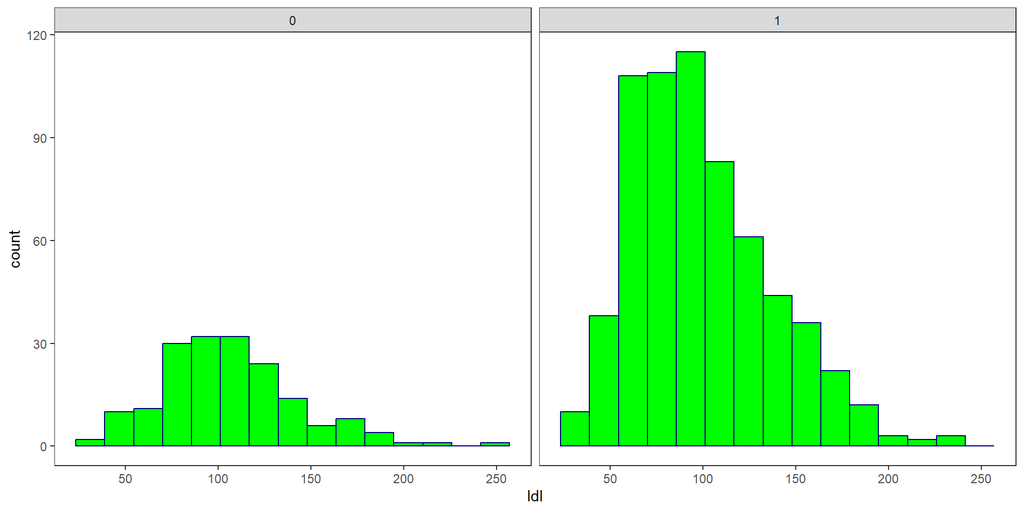

## How might we improve this plot?

1. Remove the warning about non-finite (missing) values.
2. Place the histograms vertically to ease comparisons.
3. Fill the histograms differently for statin and no statin.
4. Augment the labels (0 and 1) to show they identify statin use.

## LDL stratified by `statin` (Plot 2)

```r
tempdat <- dm1000 |> filter(complete.cases(ldl, statin))

ggplot(data = tempdat, aes(x = ldl, fill = statin)) +
  geom_histogram(bins = 15, col = "white") +
  facet_grid(statin ~ ., labeller = "label_both")
```

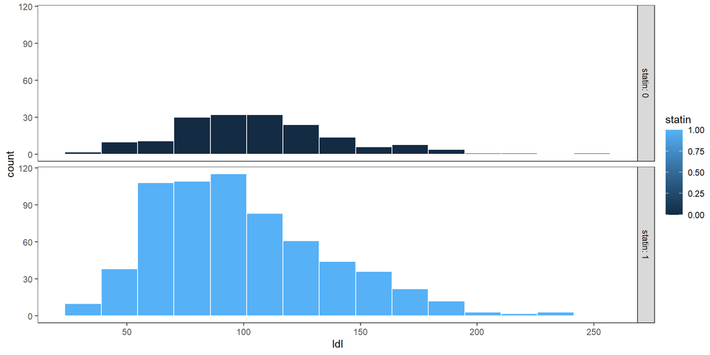

## Problems with the previous plot

1. Statin is actually a two-category variable (1 and 0 are just codes) but the legend is treating it as if it was a numeric variable.
2. Do we actually need the legend (called a guide in R) or can we remove it?

## But `statin` is categorical? (Plot 3)

```r
tempdat <- dm1000 |> filter(complete.cases(ldl, statin))
ggplot(data = tempdat, aes(x = ldl, fill = factor(statin))) +
  geom_histogram(bins = 15, col = "white") +
  facet_grid(statin ~ ., labeller = "label_both") +
  guides(fill = "none")
```

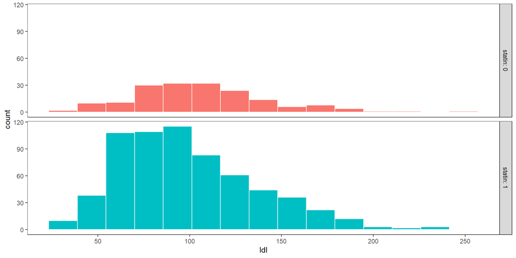

## Faceting

It’s very useful to split data into groups and plot each group separately to make comparisons across the groups. We can then draw those subplots side by side.

We have two main tools: `facet_wrap()` and `facet_grid()`

- `facet_wrap(~ grp1)` to obtain plots within each `grp1` arranged into horizontal subpanels and wrapping around, like words on a page.
- `facet_grid(grp1 ~ .)` to obtain plots within each `grp1` arranged vertically (vertical subpanels)
- `facet_grid(grp1 ~ grp2)` to obtain plots within each combination of `grp1` and `grp2` with vertical and horizontal subpanels.

## Using `facet_wrap()`

```r
tempdat <- dm1000 |> filter(complete.cases(ldl, statin))
ggplot(data = tempdat, aes(x = ldl, fill = factor(statin))) +
  geom_histogram(binwidth = 10, col = "white") +
  facet_wrap(~ statin, labeller = "label_both") +
  guides(fill = "none")
```

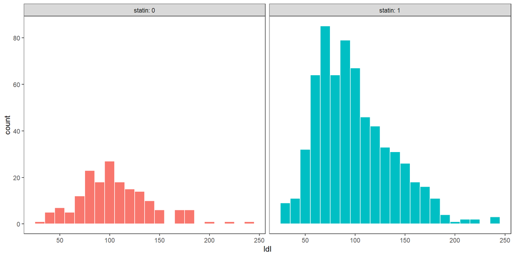

## Using `facet_grid()`

```r
tempdat <- dm1000 |> filter(complete.cases(ldl, statin))
ggplot(data = tempdat, aes(x = ldl, fill = factor(statin))) +
  geom_histogram(binwidth = 10, col = "white") +
  facet_grid(statin ~ ., labeller = "label_both") +
  guides(fill = "none")
```

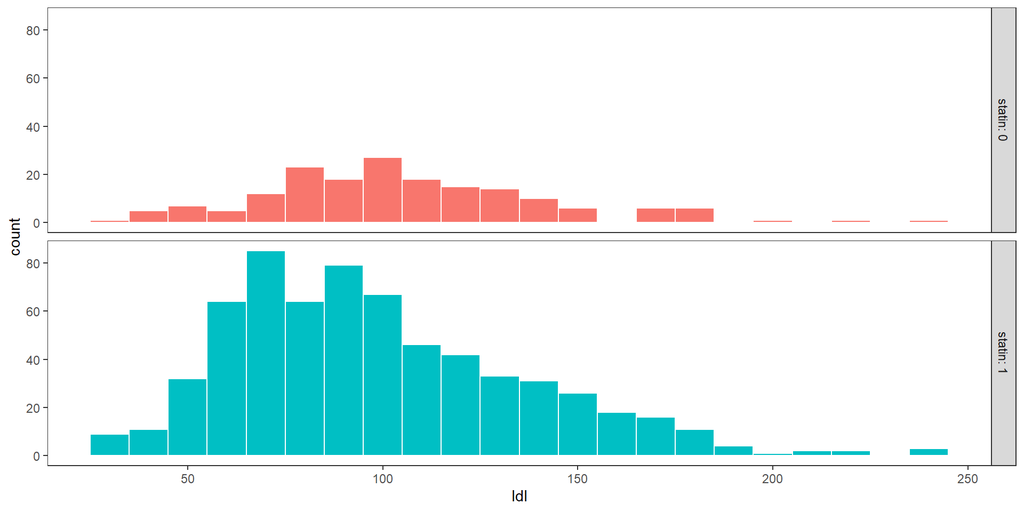

## `facet_grid()`: two groupings

```r
tempdat <- dm1000 |> filter(complete.cases(ldl, statin, residence))
ggplot(data = tempdat, aes(x = ldl, fill = factor(statin))) +
  geom_histogram(binwidth = 10, col = "white") +
  facet_grid(statin ~ residence, labeller = "label_both") +
  guides(fill = "none")
```

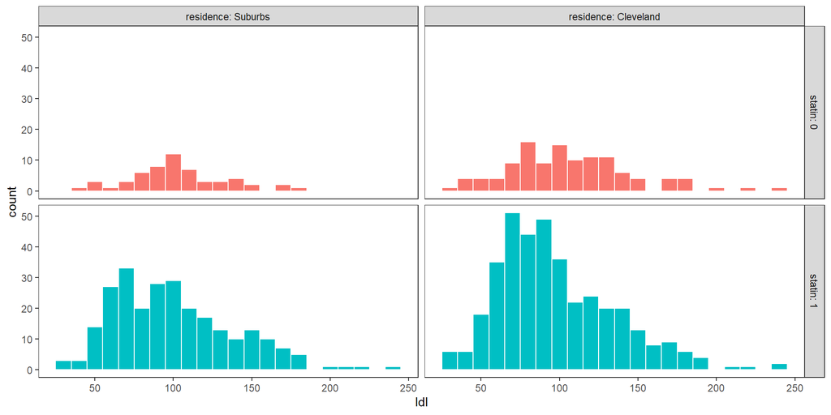

## My Main Source for `ggplot2` Visualization Recipes

https://r-graphics.org/ (Second Edition)

[figure not shown]

## Comparison of densities

This plot ignores the relative frequencies.

```r
tempdat <- dm1000 |> filter(complete.cases(ldl, statin))
ggplot(data = tempdat, aes(x = ldl, fill = factor(statin))) +
  geom_density(alpha = 0.5) + scale_fill_viridis_d() +
  labs(fill = "Statin")
```

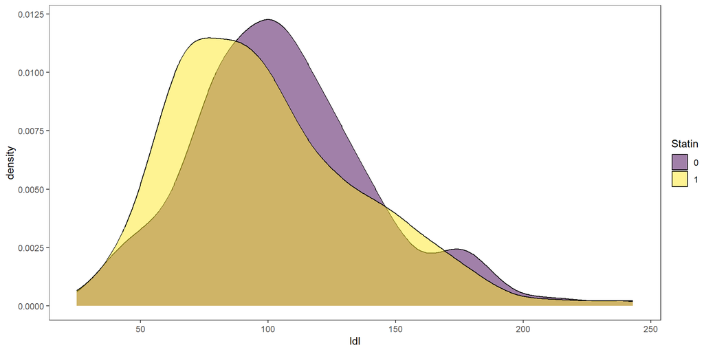

## Numerical Summaries for Two Groups

```r
dm1000 |> filter(complete.cases(statin, ldl)) |>
  group_by(statin) |>
  summarize(n = n(), min = min(ldl), med = median(ldl),
            max = max(ldl), mean = mean(ldl),
            sd = sd(ldl)) |>
  kbl(digits = 2)
```

| statin | n | min | med | max | mean | sd |
| --- | --- | --- | --- | --- | --- | --- |
| 0 | 176 | 34 | 102 | 243 | 106.22 | 36.05 |
| 1 | 646 | 25 | 92 | 241 | 99.22 | 37.21 |

- Difference in mean(LDL) between the two samples?

## Using `favstats` for LDL by Statin

```r
mosaic::favstats(ldl ~ statin, data = dm1000)
```

```
  statin min Q1 median  Q3 max      mean       sd   n missing
1      0  34 82    102 126 243 106.22159 36.04619 176      66
2      1  25 71     92 122 241  99.22136 37.20972 646     112
```

## Comparison Boxplot (LDL by statin)

Attempt 1

```r
tempdat <- dm1000 |> filter(complete.cases(ldl, statin))

ggplot(data = tempdat, aes(x = factor(statin), y = ldl)) +
  geom_violin() +
  geom_boxplot(aes(fill = factor(statin)), width = 0.3) +
  labs(x = "Statin prescription (0 = no, 1 = yes)",
       y = "LDL in mg/dl", fill = "Statin",
       title = "Boxplot for LDL by Statin (Attempt 1)")
```

## Comparison Boxplot (LDL by statin)

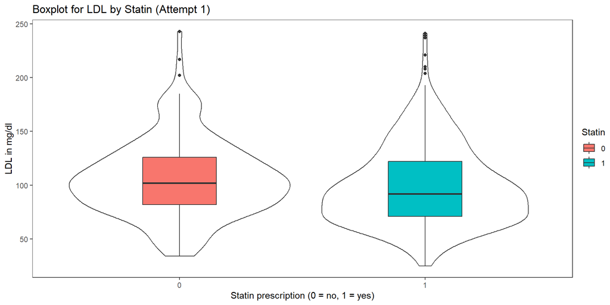

## Try 2: Boxplot for LDL and statin

```r
tempdat <- dm1000 |> filter(complete.cases(ldl, statin))

ggplot(data = tempdat, aes(x = factor(statin), y = ldl)) +
  geom_violin(aes(fill = factor(statin))) +
  geom_boxplot(width = 0.3, outlier.size = 3, notch = TRUE) +
  coord_flip() +
  guides(fill = "none") +
  labs(x = "Statin prescription (0 = no, 1 = yes)",
       y = "LDL in mg/dl",
       title = "Boxplot for LDL by Statin (Attempt 2)")
```

## Try 2: Boxplot for LDL and statin

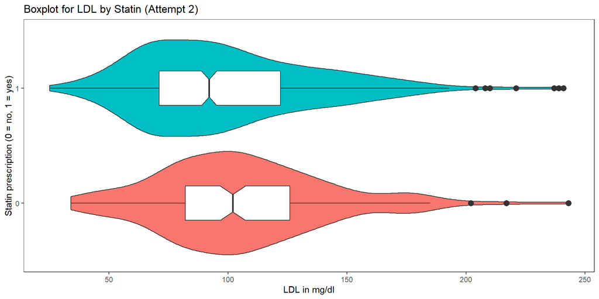

## Setting Up Third Try

```r
dm_for_boxplot <- dm1000 |>
  filter(complete.cases(statin, ldl)) |>
  mutate(statin_f = fct_recode(factor(statin),
                               "No Statin" = "0",
                               "Statin" = "1")) |>
  select(subject, ldl, statin_f, statin)

head(dm_for_boxplot, 3) # print first three rows
```

```
# A tibble: 3 × 4
  subject   ldl statin_f  statin
  <chr>   <dbl> <fct>      <dbl>
1 M-0001    221 Statin         1
2 M-0002    116 No Statin      0
3 M-0003     52 Statin         1
```

## Try 3: Boxplot of LDL by Statin

```r
ggplot(data = dm_for_boxplot, aes(x = statin_f, y = ldl)) +
  geom_violin(aes(fill = statin_f)) +
  geom_boxplot(width = 0.3, outlier.size = 3, notch = TRUE) +
  coord_flip() + guides(fill = "none") +
  scale_fill_viridis_d(begin = 0.5, option = "D") +
  labs(x = "Statin prescription",
       y = "LDL in mg/dl",
       title = "Boxplot for LDL by Statin (Attempt 3)")
```

## Try 3: Boxplot of LDL by Statin

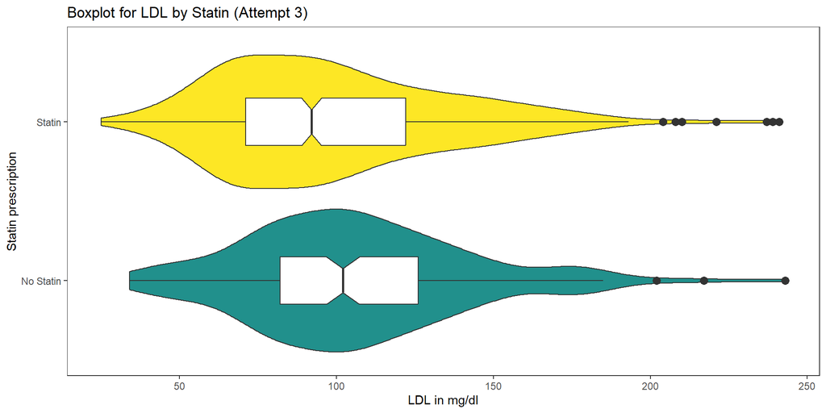

## 95% CI for difference in means

We want to estimate the difference between the population mean LDL WITH statin and population mean LDL WITHOUT statin.

The sample means, you’ll remember, are:

```r
mosaic::favstats(ldl ~ statin, data = dm1000) |>
  select(statin, n, mean, sd, missing) |>
  kbl(digits = 2) |> kable_styling(font_size = 24)
```

| statin | n | mean | sd | missing |
| --- | --- | --- | --- | --- |
| 0 | 176 | 106.22 | 36.05 | 66 |
| 1 | 646 | 99.22 | 37.21 | 112 |

## 95% CI for difference in means

- **If** we are willing to assume that LDL follows a Normal distribution in each statin group, then we can use a linear model with one predictor.

```r
m2 <- lm(ldl ~ statin, data = dm1000)
```

## Coefficients of Model `m2`

```r
m2
```

```
Call:
lm(formula = ldl ~ statin, data = dm1000)

Coefficients:
(Intercept)       statin
      106.2         -7.0
```

```r
tidy(m2, conf.int = TRUE, conf.level = 0.95) |>
  select(term, estimate, conf.low, conf.high)
```

```
# A tibble: 2 × 4
  term        estimate conf.low conf.high
  <chr>          <dbl>    <dbl>     <dbl>
1 (Intercept)   106.      101.    112.
2 statin         -7.00    -13.2    -0.831
```

## Using `t.test` to get same result

```r
mosaic::favstats(ldl ~ statin, data = dm1000) |>
  select(statin, n, mean, sd, missing) |>
  kbl(digits = 2) |> kable_styling(font_size = 24)
```

| statin | n | mean | sd | missing |
| --- | --- | --- | --- | --- |
| 0 | 176 | 106.22 | 36.05 | 66 |
| 1 | 646 | 99.22 | 37.21 | 112 |

```r
tt <- t.test(ldl ~ statin, data = dm1000,
       var.equal = TRUE, conf.level = 0.95)
tidy(tt) |> select(estimate, conf.low, conf.high) |>
  kbl(digits = 3) |> kable_styling(font_size = 32)
```

| estimate | conf.low | conf.high |
| --- | --- | --- |
| 7 | 0.831 | 13.17 |

## 95% CI for difference between population means via the bootstrap

If we are not willing to assume a Normal distribution for LDL in either the statin or the “no statin” group, then we could use a bootstrap approach.

```r
## requires the Love-boost.R script
## for the bootdif() function

set.seed(123123)
bootdif(y = dm1000$ldl, g = factor(dm1000$statin), conf.level = 0.95)
```

```
Mean Difference           0.025           0.975
     -7.0002287     -13.3055407      -0.8186563
```

## The `bootdif` function

from `Love-boost.R`

```r
`bootdif` <-
  function(y, g, conf.level=0.95, B.reps = 2000) {
    lowq = (1 - conf.level)/2
    g <- as.factor(g)
    a <- attr(Hmisc::smean.cl.boot(y[g==levels(g)[1]],
                          B=B.reps, reps=TRUE),'reps')
    b <- attr(Hmisc::smean.cl.boot(y[g==levels(g)[2]],
                          B=B.reps, reps=TRUE),'reps')
    meandif <- diff(tapply(y, g, mean, na.rm=TRUE))
    a.b <- quantile(b-a, c(lowq,1-lowq))
    res <- c(meandif, a.b)
    names(res) <- c('Mean Difference',lowq, 1-lowq)
    res
  }
```

## Assumptions behind our intervals

### Assumptions these intervals share:

- random samples from the populations of interest
- independent samples (samples aren’t paired or matched)

### Additional assumptions for linear model:

- Normal distribution in each group (statin and “no statin”)
- variance in each group (statin and “no statin”) is equal

## Comparing mean LDL by Statin

95% CIs for LDL $(\mu_{No Statin} - \mu_{Statin})$

| Approach | Estimate | 95% CI |
| --- | --- | --- |
| linear model | 7.00 | (0.83, 13.17) |
| bootstrap | 7.00 | (0.82, 13.31) |

Are our conclusions meaningfully different if we do (or do not) assume Normal population distributions of LDL within each group (statin and no statin)?

## Comparing Income by Residence

```r
tempdat <- dm1000 |> filter(complete.cases(n_income, residence))

ggplot(data = tempdat, aes(x = residence, y = n_income)) +
  geom_violin(aes(fill = residence)) +
  geom_boxplot(width = 0.3, outlier.size = 3, notch = TRUE) +
  coord_flip() + guides(fill = "none") +
  scale_fill_viridis_d(alpha = 0.5, option = "C") +
  labs(x = "Place of Residence",
       y = "Median Neighborhood Income ($)",
       title = "Boxplot for Income by Residence")
```

## Comparing Income by Residence

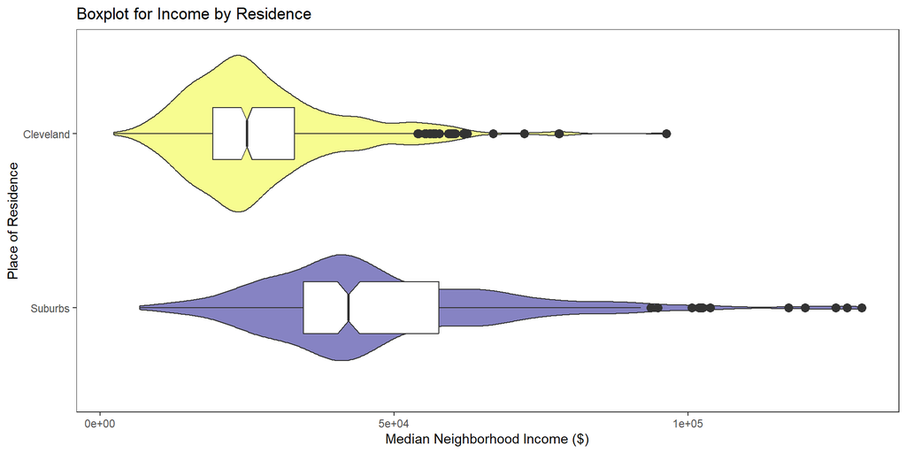

## Income Means, Medians

```r
mosaic::favstats(n_income ~ residence, data = dm1000) |>
  select(residence, n, mean, median, sd, missing) |>
  kbl(digits = 0) |> kable_styling(font_size = 32)
```

| residence | n | mean | median | sd | missing |
| --- | --- | --- | --- | --- | --- |
| Suburbs | 371 | 47251 | 42223 | 20333 | 0 |
| Cleveland | 601 | 27725 | 24907 | 13031 | 0 |

## 90% CI for Difference in Means

### Linear Model for Income by Residence

```r
m3 <- lm(n_income ~ residence, data = dm1000)
tidy(m3, conf.int = TRUE, conf.level = 0.90) |>
  select(term, estimate, conf.low, conf.high)
```

```
# A tibble: 2 × 4
  term               estimate conf.low conf.high
  <chr>                 <dbl>    <dbl>     <dbl>
1 (Intercept)          47251.   45866.    48637.
2 residenceCleveland  -19527.  -21289.   -17765.
```

### Bootstrap Approach

```r
set.seed(443322)
bootdif(y = dm1000$n_income, g = dm1000$residence,
        conf.level = 0.90)
```

```
Mean Difference            0.05            0.95
      -19526.68       -21468.71       -17545.30
```

## 90% CI for difference in mean Income

90% CIs for Income $\mu_{Suburbs} - \mu_{Cleveland}$

| Approach | Estimate | 90% CI |
| --- | --- | --- |
| linear model | 19527 | (17765, 21289) |
| bootstrap | 19527 | (17545, 21469) |

Are our conclusions meaningfully different if we do (or do not) assume Normal population distributions of neighborhood income within each residence group?

## Save `dm1000` tibble as R data set

- Preserves all changes in your R work (factors, etc.)

```r
write_rds(dm1000, "c09/data/dm_1000.Rds")
```

431 Class 09 | 2023-09-26 | https://thomaselove.github.io/431-2023/